# Fun with Sortable.js in R

Kenton Russell

2019-06-24

With `sortable` [`htmlwidget`](https://htmlwidgets.org) we can amaze our non-R friends and thrill our colleagues with powerful, dependency-free interactivity from [`Sortable.js`](https://sortablejs.github.io/Sortable/) in the browser, RStudio Viewer, or RStudio Shiny. I encourage you to **think creatively and imaginatively** with `sortable` as there are all sorts of potential uses for this `htmlwidget`. Please do not limit yourself to the simple examples within this vignette.

```r
library(sortable)
```

## Super Simple Example

Using `sortable` in markdown is a little tricky since markdown does not provide an easy way to provide an `id` that we’ll need. We can overcome this by using bare `HTML` or using `htmltools::tags`. Let’s make a simple `ul` list. Note, however, that `sortable` works with nearly any `HTML` element, such as `div`.

[output not shown]

#### drag me

#### sort me

#### touch (yes touch) me

#### any way you like

```r
sortable_js( "example01" )
```

[interactive chart not shown]

Now let’s use the `htmltools::tags` approach to do exactly the same thing.

```r
library(htmltools)
tagList(
  tags$ul(
    id = "example02",
    tags$li(tags$h4("drag me")),
    tags$li(tags$h4("sort me")),
    tags$li(tags$h4("touch (yes touch) me")),
    tags$li(tags$h4("any way you like"))
  ),
  sortable_js("example02")
)
```

#### drag me

#### sort me

#### touch (yes touch) me

#### any way you like

[interactive chart not shown]

## Little Harder but Better Example

If you were wondering if `sortable` works with images, of course it does. We’ll use `base64::img` to embed our plots on the page.

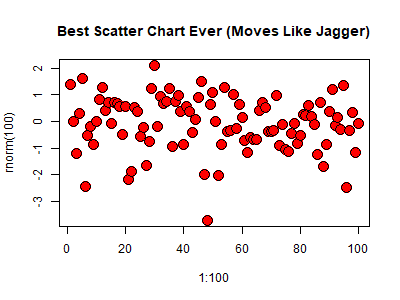

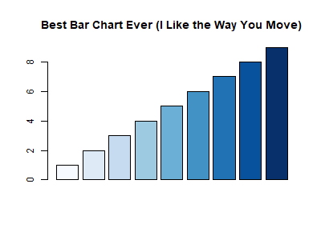

[interactive chart not shown]

```r
library(base64)

# use example from ?base64::img
pngfile <- tempfile()
png(pngfile, width = 400, height = 300)
plot(1:100, rnorm(100), pch = 21, bg = "red", cex = 2)
title(main = "Best Scatter Chart Ever (Moves Like Jagger)")
msg <- capture.output(dev.off())


# make another plot for demo purposes
pngfile2 <- tempfile()
png(pngfile2, width = 400, height = 300)
barplot(1:9, col = blues9)
title(main = "Best Bar Chart Ever (I Like the Way You Move)")
msg <- capture.output(dev.off())

tagList(
  tags$div(
    id = "example03",
    HTML(img(pngfile)),
    HTML(img(pngfile2))
  ),
  sortable_js("example03")
)
```

## Power of Groups

Looking at the [`Sortable.js`](https://github.com/SortableJS/Sortable#options) excites me about the potential to use `sortable` as an important UI element in both a Shiny and non-Shiny context. We could potentially demo a plot builder with something like this example. You’ll notice that it doesn’t really do anything, but I hope the intent and direction is clear.

```r
library(shiny)
fluidPage(
  fluidRow(
    class = "panel panel-success",
    tags$div(
      class = "panel-heading",
      tags$h3("Magic Can Happen Here")
    ),
    fluidRow(
      class = "panel-body",
      column(
        width = 4,
        tags$div(
          class = "panel panel-default",
          tags$div(class = "panel-heading", "Variables"),
          tags$div(
            class = "panel-body",
            id = "sort1",
            lapply(
              colnames(mtcars),
              function(co) {
                tag(
                  "p",
                  list(
                    class = class(mtcars[, co]),
                    tags$span(class = "glyphicon glyphicon-move"),
                    tags$strong(co)
                  ))})))),
      column(
        width = 4,
        tags$div(
          class="panel panel-default",
          tags$div(
            class="panel-heading",
            tags$span(class = "glyphicon glyphicon-stats"),
            "Analyze as x (drag here)"
          ))),
      column(
        width = 4,
        tags$div(
          class = "panel panel-default",
          tags$div(
            class = "panel-heading",
            tags$span(class = "glyphicon glyphicon-stats"),
            "Analyze as y (drag here)"
          ),
          tags$div(
            class = "panel-body",
            id = "sort3"
          ))),
      column(
        width = 4,
        tags$div(
          class="panel panel-default",
          tags$div(
            class="panel-heading",
            tags$span(class = "glyphicon glyphicon-stats"),
            "Analyze as y (drag here)"
          ),
          tags$div(
            class="panel-body",
            id = "sort3"
          ))))),
  sortable_js("sort1", options = sortable_options(group = "sortGroup1")),
  sortable_js("sort2", options = sortable_options(group = "sortGroup1")),
  sortable_js("sort3", options = sortable_options(group = "sortGroup1"))
)
```

**Variables**

**mpg**

**cyl**

**disp**

**hp**

**drat**

**wt**

**qsec**

**vs**

**am**

**gear**

**carb**

**Analyze as x (drag here)**

**Analyze as y (drag here)**

**Analyze as y (drag here)**

[interactive chart not shown]

## Code For a Shiny Example

I learned late last night that `sortable` will allow movable tabs inside a Shiny (and also not Shiny) app. By adding just one line of code and an `id` to this RStudio [Tabset example](https://github.com/rstudio/shiny-examples/tree/master/006-tabsets), we get rearrangeable tabs. I really hope you’ll copy and paste to see it for yourself, or you can `runGist("2dbe45f77b65e28acab9")`.

```r
# all credit for code goes to RStudio
# https://github.com/rstudio/shiny-examples/tree/master/006-tabsets
library(sortable)
library(shiny)

ui = # Define UI for random distribution application
shinyUI(fluidPage(

  # Application title
  titlePanel("Tabsets"),

  # Sidebar with controls to select the random distribution type
  # and number of observations to generate. Note the use of the
  # br() element to introduce extra vertical spacing
  sidebarLayout(
    sidebarPanel(
      radioButtons(
        "dist", "Distribution type:",
        c(
          "Normal" = "norm",
          "Uniform" = "unif",
          "Log-normal" = "lnorm",
          "Exponential" = "exp"
        )
      ),
      br(),

      sliderInput(
        "n",
        "Number of observations:",
         value = 500,
         min = 1,
         max = 1000)
    ),

    # Show a tabset that includes a plot, summary, and table view
    # of the generated distribution
    mainPanel(
      tabsetPanel(
        type = "tabs",
        id = "sortTab",
        tabPanel("Plot", plotOutput("plot")),
        tabPanel("Summary", verbatimTextOutput("summary")),
        tabPanel("Table", tableOutput("table"))
      )
    )
  ),
  sortable_js("sortTab")
))

server = function(input, output) {

  # Reactive expression to generate the requested distribution.
  # This is called whenever the inputs change. The output
  # functions defined below then all use the value computed from
  # this expression
  data <- reactive({
    dist <- switch(
      input$dist,
      norm = rnorm,
      unif = runif,
      lnorm = rlnorm,
      exp = rexp,
      rnorm
    )

    dist(input$n)
  })

  # Generate a plot of the data. Also uses the inputs to build
  # the plot label. Note that the dependencies on both the inputs
  # and the data reactive expression are both tracked, and
  # all expressions are called in the sequence implied by the
  # dependency graph
  output$plot <- renderPlot({
    dist <- input$dist
    n <- input$n

    hist(data(),
         main=paste('r', dist, '(', n, ')', sep=''))
  })

  # Generate a summary of the data
  output$summary <- renderPrint({
    summary(data())
  })

  # Generate an HTML table view of the data
  output$table <- renderTable({
    data.frame(x = data())
  })

}

shinyApp( ui, server )
```

## Conclusion

**Think big with this little `htmlwidget`**.

## Thanks

With powerful tools from generous people, amazing things can be easily accomplished. Thanks to:

- [R](https://r-project.org)
- [Ramnath Vaidyanathan](https://github.com/ramnathv) and [RStudio](https://rstudio.com) for [`htmlwidgets`](https://htmlwidgets.org)
- [@RubaXa](https://github.com/RubaXa) for [`Sortable`](https://sortablejs.github.io/Sortable/)